# R Markdown Demo

# Introduction

- Combine text and code
- Code is written is chunks, text is around chunks
- Render to various outputs: PDF, slides, HTML, Word, …
- Use templates
- Embed interactive elements with Shiny
- Great for analyzing data
- Plots adapt with code/data changes upon rendering
- Let others try out things, e.g. change parameters and re-run
- Installation: `install.packages("rmarkdown")`

# Create a new R Markdown Document

Easiest way: `RStudio > File > New File > R Markdown`

But: you can use any other text editor. Good support is offered by Emacs, inferior support by other editors like VS Code.

# YAML Metadata Section

Metadata for the document are given inside the

```
---

---
```

at the beginning of the document. You don’t need to learn YAML (it’s just key-value pairs, anyway), most stuff can be filled in automatically.

# Markdown

## We already know what this is!

Refer to Konstantin’s presentation and https://github.com/adam-p/markdown-here/wiki/Markdown-Cheatsheet for reference.

## A few examples

### Embed a picture

[figure not shown]

R Markdown is fantastic!

### Embed LaTeX math

$\Delta\Psi_{ww} = \frac{1}{T}\int_{0}^{T}\Delta\Psi\left(t\right) dt \approx const.$

(also appears on hover-over in the editor)

# Code Chunks

## Basic anatomy

```r
1 + 1
```

```
## [1] 2
```

```r
sin(pi/2)
```

```
## [1] 1
```

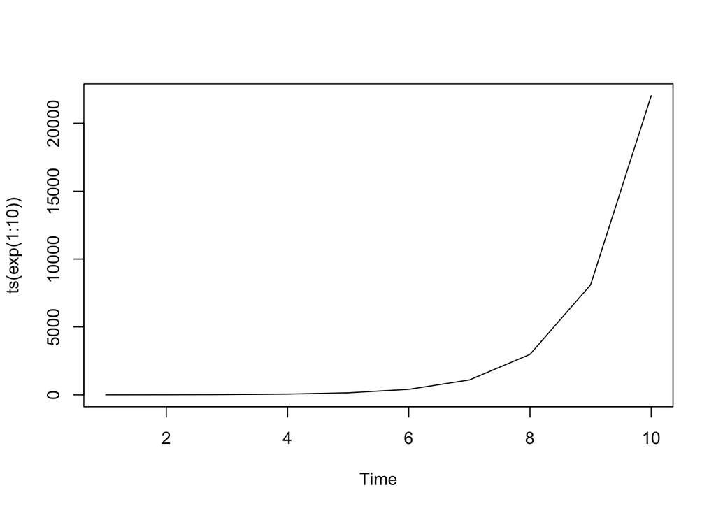

```r
plot(ts(exp(1:10)))
```

## Inline rendering

Can be turned on/off in options.

## Naming chunks

```r
cat("what a great chunk of code!\n")
```

```
## what a great chunk of code!
```

## Chunk options

### Hiding the code

```
## you won't see the code behind me!
```

### Hiding the output

```r
cat("you won't see the results, only the code!\n")
```

### Hide both code and output

Don’t worry if you don’t see anything here, that’s the intended behaviour!

### Caching results

For long-running computations, it makes perfect sense to cache the results. R Markdown has a mechanism for determining when it’s time to evualate the code again (e.g., checksum of dependencies has changed), but you can also do this manually.

```r
z <- numeric(1e8)
```

## Other languages

Just some examples of what is possible.

### Bash

```bash
printf "hello\nyellow\nmellow\nworld" | grep 'ello' | sort
```

### Python

Python needs the reticulate package, don’t do this now, it takes a while!

```python
5 + 8
```

### C++ with Rcpp

```cpp
#include <Rcpp.h>
using namespace Rcpp;

// [[Rcpp::export]]
NumericVector timesTwo(NumericVector x) {
  return x * 2;
}
```

```r
timesTwo(3)
```

```
## [1] 6
```

# Inline Code

```r
answer <- 42
```

The answer is 42.

# Figure options

Set width, height, figure caption etc.

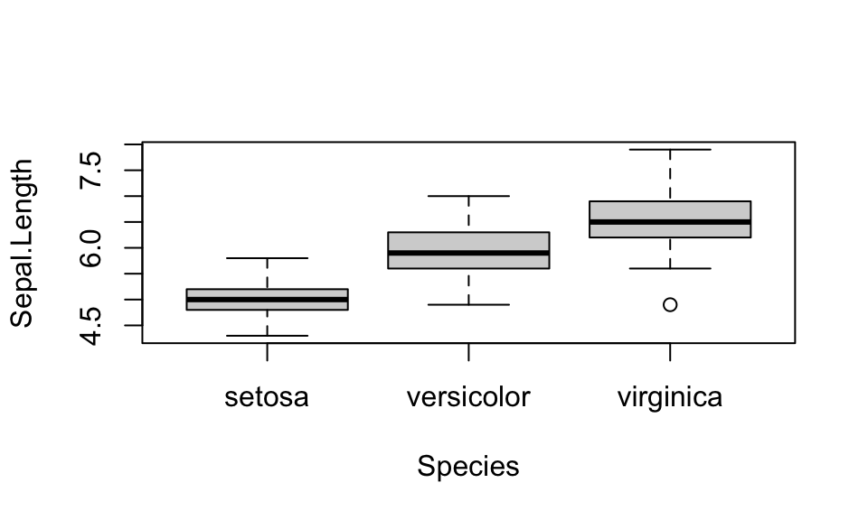

This figure has a a caption!

```r
boxplot(Sepal.Length ~ Species, data = iris)
```

# Tables

`knitr::kable` is one possible way:

```r
knitr::kable(mtcars[1:5,])
```

|  | mpg | cyl | disp | hp | drat | wt | qsec | vs | am | gear | carb |
| --- | --- | --- | --- | --- | --- | --- | --- | --- | --- | --- | --- |
| Mazda RX4 | 21.0 | 6 | 160 | 110 | 3.90 | 2.620 | 16.46 | 0 | 1 | 4 | 4 |
| Mazda RX4 Wag | 21.0 | 6 | 160 | 110 | 3.90 | 2.875 | 17.02 | 0 | 1 | 4 | 4 |
| Datsun 710 | 22.8 | 4 | 108 | 93 | 3.85 | 2.320 | 18.61 | 1 | 1 | 4 | 1 |
| Hornet 4 Drive | 21.4 | 6 | 258 | 110 | 3.08 | 3.215 | 19.44 | 1 | 0 | 3 | 1 |
| Hornet Sportabout | 18.7 | 8 | 360 | 175 | 3.15 | 3.440 | 17.02 | 0 | 0 | 3 | 2 |

# Citations

I am citing my favourite paper here (Bastin et al. 2019). Note that the bibliography is placed at the end of the document.

# R Markdown vs. “R Notebooks”

# Sharing and Collaborating

## GitHub

### Read-only

- GitHub can render *.Rmd files nicely (static page)

### Real collaboration

- *.Rmd files are plain text, so a regular GitHub-flow is possible
- standard tools for diff’ing, etc.

## Binder

Takes a few steps more than for a Jupyter Notebook, but still quite manageable. See here for details and instructions: https://kbroman.org/blog/2019/02/18/omg_binder/

# Resources

https://bookdown.org/yihui/rmarkdown/

# References

Bastin, Jean-Francois, Yelena Finegold, Claude Garcia, Danilo Mollicone, Marcelo Rezende, Devin Routh, Constantin M. Zohner, and Thomas W. Crowther. 2019. “The Global Tree Restoration Potential.” *Science* 365 (6448): 76–79. https://doi.org/10.1126/science.aax0848.